# Decision Trees

## Where we left off

- **Days 12–14:** two ways to classify.
  - Logistic regression: one S-curve, so a straight boundary.
  - KNN: a vote of the nearest cases, so a boundary of any shape.
  - Compared fairly with cross-validation (Day 14).
- **Today: decision trees.** A third way.
  - A short list of yes/no questions, found from the data.
  - Reads like a flowchart; anyone can follow it.

## Who graduates with heavy debt?

> **2,000 graduates: family income, SAT score, and whether they left with more than $30k of debt. What’s the pattern?**

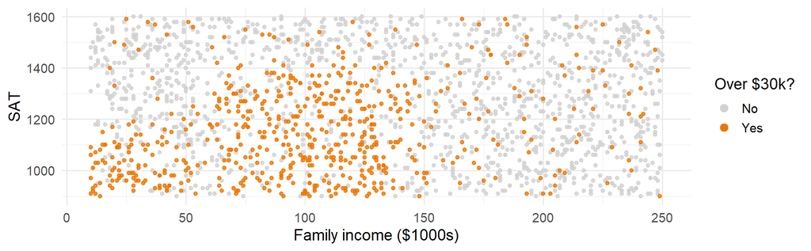

- Simulated, but the logic is real: need-based aid, merit aid, and a squeezed **middle**. Eight more columns too (rent, work hours, savings, …).

## A tree finds the pattern

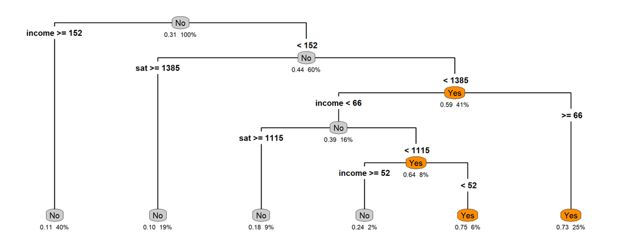

- Follow the true branch down. **Leaves:** the majority class and the share with heavy debt. It used 2 of the 10 predictors: income and SAT.

## The same tree as boxes

> **Where does the tree predict heavy debt?**

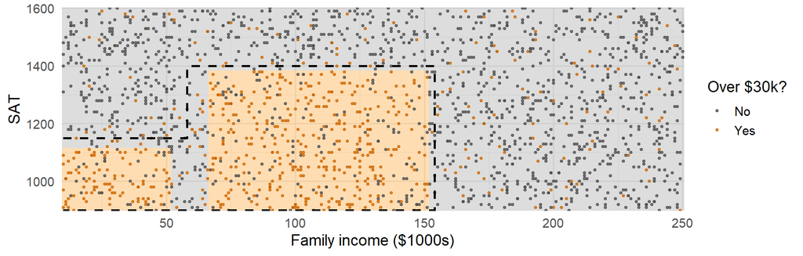

- Each question cuts **one** predictor at a cutoff, so the regions are rectangles.
- Dashed: the true rule. Low income: debt unless SAT ≥ 1150 (need-based aid). Middle income: debt unless SAT ≥ 1400 (merit aid). High income: no debt.

## Three ways to carve up the space

> **Fit on income and SAT only. Where does each method predict heavy debt?**

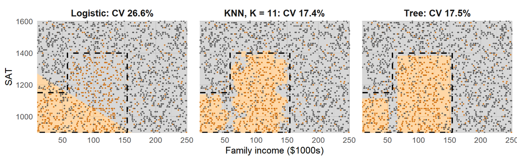

- **Logistic:** one straight line. It can’t make the staircase, or stop at high income.
- **KNN:** close to the staircase, with ragged edges. **Tree:** the staircase, almost exactly.

## When the boundary is diagonal

> **A new problem: admission from GPA and SAT. A higher SAT makes up for a lower GPA.**

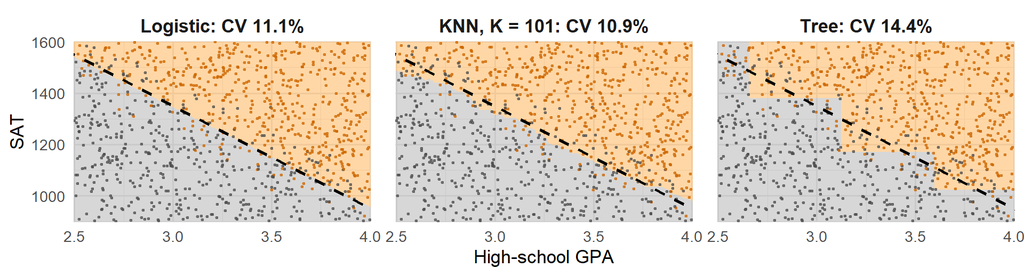

- Dashed: the true rule. **Logistic** draws it exactly, **KNN** follows it, **the tree** needs a staircase.
- No method wins everywhere: the shape of the boundary decides, and CV tells you which.

## Add the other eight columns

> **Now every method gets all 10 predictors. Who gets hurt?** CV error (same 5 folds).

| Method | Income and SAT only | All 10 predictors |
| --- | --- | --- |
| Logistic regression | 26.6% (SE 0.4%) | 22.8% (SE 0.6%) |
| KNN (best K: 11, then 25) | 17.4% (SE 0.9%) | 21.8% (SE 0.6%) |
| **Tree** | **17.5% (SE 0.8%)** | **18.1% (SE 1.0%)** |

- **KNN** gets worse: 8 more columns count in every distance, so “nearest” students aren’t similar on income and SAT anymore.
- **The tree** barely changes: it keeps asking about income and SAT.
- **Logistic** improves a little from the new columns, but still can’t find the staircase.

## 1. Growing a tree

## What makes a good question?

> **A class of 100 students; half (50) are data science majors. You want to guess which ones. You get one yes/no question. What would you ask?**

**(1)** “Have you taken a programming class?” **(2)** “Born in January–June?”

| Question | Answer | Students | Data science majors | Share majors |
| --- | --- | --- | --- | --- |
| **Taken a programming class?** | Yes | 50 | 45 | 90% |
|  | No | 50 | 5 | 10% |
| **Birthday in January-June?** | Yes | 50 | 25 | 50% |
|  | No | 50 | 25 | 50% |

- **Good:** each group is **mostly one kind** (“No” → almost surely not a major).
- **Bad:** both groups look like the whole class (50%). Next: a number for “mixed.”

## Measuring impurity: the Gini index

**Impurity** = how mixed a group is. Trees use the **Gini index**: \(\;G = 2p(1 - p)\), where \(p\) = share in one class (here: majors).

| Group | Share majors, p | Gini, G |
| --- | --- | --- |
| All majors, or no majors (pure) | 1.00 or 0.00 | 0.00 |
| **Half and half, like the whole class** (most mixed) | 0.50 | 0.50 |

- A question’s **score**: its two groups’ \(G\), averaged by group size. Lower is better.
  - Programming class: (50 × 0.18 + 50 × 0.18) / 100 = **0.18**.
  - Birthday: (50 × 0.50 + 50 × 0.50) / 100 = **0.50**, the same as not asking.

## How does it pick the first question?

> **Back to student debt. Score every cutoff on every predictor: which question wins?**

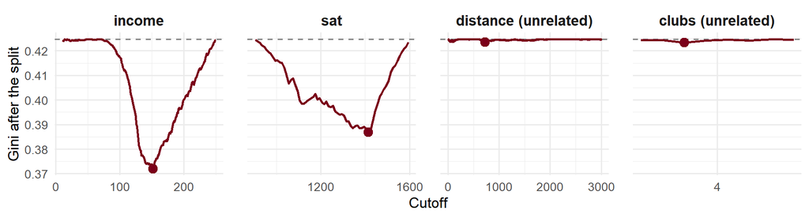

- Each point is one question (“income < 50?”, “income < 51?”, …), scored the same way. Dashed: before any split (0.42). Dot: each predictor’s best.
- The winner: income at 151.5. Above it, almost nobody has heavy debt. Unrelated columns stay on the dashed line.

## Then repeat inside each box

- **Recursive binary splitting** (ISL 8.1):
  - Split the data in two with the best question.
  - Do the same inside each half, and inside each half of those, …
  - Here: among income < 151.5, the best question is about sat (merit aid), then income again.
- **Greedy:** each split is the best one *right now*. It never looks ahead.
- **When to stop?** `rpart`’s defaults stop when a box is small (under 20 students) or a split barely helps. Here: 6 leaves.

```r
tree <- rpart(heavy_debt ~ ., data = students, method = "class")   # rpart package
rpart.plot(tree, type = 4)                                         # rpart.plot package
```

## Regression trees: predict a number, not Yes/No

> **How much debt, in dollars?** (Before: just Yes/No.)

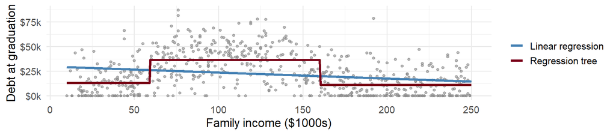

- Students with SATs of 1150–1390 (no merit aid). Predict debt from family income.
- For a **continuous** outcome (dollars, prices, scores) instead of a category.
- Each leaf predicts its cases’ **mean** ($13k, $36k, $11k). The line can’t make the hump.
- Splits minimize the **RSS** (Day 10). Same `rpart()`, no `method = "class"`.

## 2. How flexible is a tree?

## Grow it all the way

> **No stopping rule: split until every leaf is pure. Is that a better tree?**

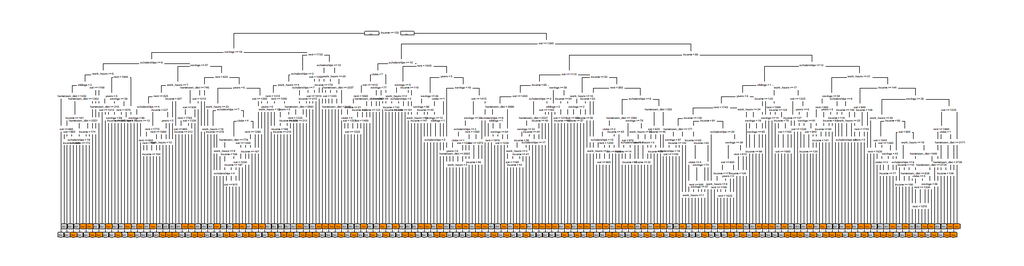

- 282 leaves. **Training error 0.0%**, but **CV error 23.8%** (vs 18.1% for the 6-leaf tree). It boxed in every exception, like KNN with \(K = 1\).

## Trees: strengths and weaknesses

| Strengths | Weaknesses |
| --- | --- |
| Easy to explain: a flowchart | Diagonal or smooth boundaries take many boxes |
| Cutoffs and “and” rules come naturally | Often less accurate than other methods |
| Ignores predictors that don’t help | **Unstable:** new data can change the whole tree |
| No standardizing: a cutoff doesn’t care about units | Too many leaves overfit, like *K* = 1 |

- If aid phased out along a diagonal (a points formula of income and SAT), the tree would need a staircase. **The activity:** the colleges, where the boundary is closer to a line.
- Next: **pruning** (Day 16), then **many trees** averaged together (Days 17–18).

## Summary

A **decision tree** predicts with a sequence of yes/no questions about the predictors.

- Each split cuts one predictor at a cutoff; the leaves are **rectangles** in predictor space.
- **Classification:** predict a leaf’s majority class; splits minimize the **Gini index**.
- **Regression:** predict a leaf’s mean; splits minimize the **RSS**.
- Grown top-down and greedily, one best split at a time.
- Wins when the truth is a few cutoffs and some predictors don’t matter (the debt squeeze).
- Flexibility = **number of leaves**. Grown until pure, training error is 0%.

**Next time:** pruning. How many leaves should a tree have? (Cross-validation, again.)

## For rest of class

- Work on the `day15_activity`
  - back to the colleges: grow a tree, read it, and score it with Day 14’s CV loop
  - does the tree beat logistic regression and KNN there?
- Ask me questions if you run into issues